# Task

in relation to the Gujarati book (basic econometrics), answer question 22.25 pp 800: Table 22.7 gives data on three-month (TB3M) and six-month (TB6M) Treasury bill rates from January 1, 1982, to March 2008, for a total of 315 monthly observations. The data can be found on the textbook's website. to. Plot the two time series in the same diagram. What do you see? b. Do a formal unit root analysis to find out if these time series are stationary. c. Are the two time series cointegrated? How do you know? Show the necessary calculations. d. What is the economic meaning of cointegration in the present context? If the two series are not cointegrated, what are the economic implications? and. If you want to estimate a VAR model, say, with four lags of each variable, do you have to use the first differences of the two series or can you do the analysis in levels of the two series? Justify your answer.

Here is all the data you need: "Table 22.7.txt"

## Data loading

### Subtask:

Load the data from "Table 22.7.txt" into a pandas DataFrame.

**Reasoning**: Load the data from "Table 22.7.txt" into a pandas DataFrame, handling the date column and ensuring correct data types.

```python
import pandas as pd

# Load the data, handling the date column and ensuring correct data types.
try:
    df = pd.read_csv('Table 22.7.txt', sep='\t', header=0, index_col=0, parse_dates=True, names=['Date', 'TB3M', 'TB6M'])
    # Display the first few rows of the DataFrame
    display(df.head())
    # Display the last few rows of the DataFrame
    display(df.tail())
    # Display the shape of the DataFrame
    print(f"Shape of the DataFrame: {df.shape}")
    # Display the data types of each column
    print(f"Data types of each column:\n{df.dtypes}")

except FileNotFoundError:
    print("Error: 'Table 22.7.txt' not found. Please ensure the file exists in the current directory.")
    df = None # Set df to None to indicate an error
except pd.errors.ParserError:
    print("Error: Could not parse the file. Check the file format and delimiters.")
    df = None # Set df to None to indicate an error
except Exception as e:
    print(f"An unexpected error occurred: {e}")
    df = None # Set df to None to indicate an error
```

```
Error: Could not parse the file. Check the file format and delimiters.
```

**Reasoning**: The previous attempt to load the data failed due to a parsing error. I'll try again with a different delimiter and check for potential issues like spaces in the data.

```python
import pandas as pd

try:
    # Try different delimiters and skiprows if needed
    df = pd.read_csv('Table 22.7.txt', delim_whitespace=True, header=0, index_col=0, parse_dates=True, names=['Date', 'TB3M', 'TB6M'])

    # Check for missing values
    if df.isnull().values.any():
        print("Warning: Missing values detected in the DataFrame.")
        # Decide how to handle missing values: remove rows, fill with mean/median, etc.
        # Example: Remove rows with missing values
        df = df.dropna()  # Or use other methods like fillna()

    display(df.head())
    display(df.tail())
    print(f"Shape of the DataFrame: {df.shape}")
    print(f"Data types of each column:\n{df.dtypes}")
except FileNotFoundError:
    print("Error: 'Table 22.7.txt' not found. Please ensure the file exists in the current directory.")
    df = None
except pd.errors.ParserError:
    print("Error: Could not parse the file. Please check the file format and delimiters.")
    df = None
except Exception as e:
    print(f"An unexpected error occurred: {e}")
    df = None
```

```
Error: Could not parse the file. Please check the file format and delimiters.
```

[output not shown]

**Reasoning**: The previous attempts to load the data have failed. I will try one more time using `sep='\s+'` as suggested by the warning, and I will add more robust error handling. I will also attempt to convert the 'TB3M' and 'TB6M' columns to numeric after loading, as this is crucial for further analysis.

```python
import pandas as pd

try:
    df = pd.read_csv('Table 22.7.txt', sep='\s+', header=0, index_col=0, parse_dates=True, names=['Date', 'TB3M', 'TB6M'])

    # Convert 'TB3M' and 'TB6M' columns to numeric, handling errors
    for col in ['TB3M', 'TB6M']:
        try:
            df[col] = pd.to_numeric(df[col], errors='coerce')
        except Exception as e:
            print(f"Error converting column '{col}' to numeric: {e}")
            # Handle the error appropriately, e.g., set df to None or remove the column

    # Check for missing values after conversion
    if df.isnull().values.any():
        print("Warning: Missing values detected after conversion to numeric.")
        # Handle missing values, e.g., remove rows or fill with a suitable value
        df.dropna(inplace=True) # remove rows with missing values

    display(df.head())
    display(df.tail())
    print(f"Shape of the DataFrame: {df.shape}")
    print(f"Data types of each column:\n{df.dtypes}")

except FileNotFoundError:
    print("Error: 'Table 22.7.txt' not found.")
    df = None
except pd.errors.ParserError:
    print("Error: Could not parse the file. Check the file format and delimiters.")
    df = None
except Exception as e:
    print(f"An unexpected error occurred: {e}")
    df = None
```

```
Error: Could not parse the file. Check the file format and delimiters.
```

**Reasoning**: All attempts to load the data using `pd.read_csv` have failed. I will try using `pd.read_table` which might be more suitable for data with irregular spacing. I'll also explicitly handle potential errors during the conversion of the TB3M and TB6M columns to numeric data, as well as missing values.

```python
import pandas as pd

try:
    df = pd.read_table('Table 22.7.txt', header=0, index_col=0, parse_dates=True, names=['Date', 'TB3M', 'TB6M'])

    # Convert 'TB3M' and 'TB6M' columns to numeric, handling errors
    for col in ['TB3M', 'TB6M']:
      df[col] = pd.to_numeric(df[col], errors='coerce')

    # Handle potential missing values after conversion
    df.dropna(inplace=True)

    display(df.head())
    display(df.tail())
    print(f"Shape of the DataFrame: {df.shape}")
    print(f"Data types of each column:\n{df.dtypes}")

except FileNotFoundError:
    print("Error: 'Table 22.7.txt' not found.")
    df = None
except pd.errors.ParserError:
    print("Error: Could not parse the file.")
    df = None
except Exception as e:
    print(f"An unexpected error occurred: {e}")
    df = None
```

```
Error: Could not parse the file.
```

## Data loading

### Subtask:

Load the data from "Table 22.7.txt" into a pandas DataFrame.

**Reasoning**: Based on the history, the previous attempts to load the data failed due to parsing errors. I'll try one more time with `pd.read_csv`, explicitly setting the delimiter to a single space, and using a more robust method to handle non-numeric values. I will also check the date range and the number of rows.

```python
import pandas as pd

try:
    # Try reading the file with a single space as the delimiter
    df = pd.read_csv('Table 22.7.txt', delim_whitespace=True, header=0, index_col=0, parse_dates=True, names=['Date', 'TB3M', 'TB6M'])

    # Convert columns to numeric, coercing errors to NaN
    for col in ['TB3M', 'TB6M']:
        df[col] = pd.to_numeric(df[col], errors='coerce')

    # Drop rows with NaN values
    df.dropna(inplace=True)

    # Display basic info
    display(df.head())
    display(df.tail())
    print(f"Shape of the DataFrame: {df.shape}")
    print(f"Data types of each column:\n{df.dtypes}")
    print(f"Number of rows: {len(df)}")
    print(f"Date range: {df.index.min()} to {df.index.max()}")

except FileNotFoundError:
    print("Error: 'Table 22.7.txt' not found.")
    df = None
except pd.errors.ParserError:
    print("Error: Could not parse the file. Check the file format and delimiters.")
    df = None
except Exception as e:
    print(f"An unexpected error occurred: {e}")
    df = None
```

```
Error: Could not parse the file. Check the file format and delimiters.
```

**Reasoning**: The previous attempts to load the data using `pd.read_csv` and `pd.read_table` have failed. The error message suggests issues with the file format and delimiters. I will try one last time using `pd.read_fwf` which is designed to handle fixed-width formatted files, which seems to be the case here. Given the repeated failures with other methods, this is the last resort. I will also try to explicitly set the column widths.

```python
import pandas as pd

try:
    # Attempt to read the file using pd.read_fwf
    colspecs = [(0, 9), (10, 16), (17, 23)]  # Adjust column widths if needed
    df = pd.read_fwf('Table 22.7.txt', colspecs=colspecs, header=None, index_col=0, names=['Date', 'TB3M', 'TB6M'], parse_dates=True)

    # Convert columns to numeric, coercing errors
    for col in ['TB3M', 'TB6M']:
        df[col] = pd.to_numeric(df[col], errors='coerce')

    # Handle missing values
    df.dropna(inplace=True)

    # Display info
    display(df.head())
    display(df.tail())
    print(f"Shape of the DataFrame: {df.shape}")
    print(f"Data types of each column:\n{df.dtypes}")
    print(f"Number of rows: {len(df)}")
    print(f"Date range: {df.index.min()} to {df.index.max()}")

except FileNotFoundError:
    print("Error: 'Table 22.7.txt' not found.")
    df = None
except pd.errors.ParserError:
    print("Error: Could not parse the file. Check the file format and delimiters.")
    df = None
except Exception as e:
    print(f"An unexpected error occurred: {e}")
    df = None
```

| Date | TB3M | TB6M |
| --- | --- | --- |
| 1982:01 | 2.92 | 13.9 |
| 1982:02 | 4.28 | 14.8 |
| 1982:03 | 3.31 | 13.8 |
| 1982:04 | 3.34 | 13.8 |
| 1982:05 | 2.71 | 13.1 |

| Date | TB3M | TB6M |
| --- | --- | --- |
| 2001:02 | 0.01 | 4.89 |
| 2001:03 | 0.54 | 4.44 |
| 2001:04 | 0.97 | 3.99 |
| 2001:05 | 0.70 | 3.74 |
| 2001:06 | 0.57 | 3.56 |

```
Shape of the DataFrame: (234, 2)
Data types of each column:
TB3M    float64
TB6M    float64
dtype: object
Number of rows: 234
Date range: 1982:01 to 2001:06
```

## Data exploration

### Subtask:

Explore and understand the loaded data.

**Reasoning**: Explore and understand the loaded data by checking data types, shape, missing values, descriptive statistics, and time period.

```python
# Check data types
print(df.dtypes)

# Check for missing values
print(df.isnull().sum())

# Descriptive statistics
print(df.describe())

# Verify time period
print(f"Start date: {df.index.min()}")
print(f"End date: {df.index.max()}")

# Check the shape of the DataFrame
print(f"Shape of the DataFrame: {df.shape}")

# Summary
print("\nSummary:")
print(f"The DataFrame has {df.shape[0]} rows and {df.shape[1]} columns.")
print(f"The data covers the period from {df.index.min()} to {df.index.max()}.")
if df.isnull().values.any():
    print("Missing values were found in the data.")
else:
    print("No missing values were found in the data.")
```

```
TB3M    float64
TB6M    float64
dtype: object
TB3M    0
TB6M    0
dtype: int64
             TB3M        TB6M
count  234.000000  234.000000
mean     0.529274    6.561197
std      0.552736    2.301820
min      0.000000    3.040000
25%      0.180000    5.230000
50%      0.405000    6.035000
75%      0.750000    7.950000
max      4.280000   14.800000
Start date: 1982:01
End date: 2001:06
Shape of the DataFrame: (234, 2)

Summary:
The DataFrame has 234 rows and 2 columns.
The data covers the period from 1982:01 to 2001:06.
No missing values were found in the data.
```

## Data visualization

### Subtask:

Visualize the time series data for TB3M and TB6M rates.

**Reasoning**: Create the plot of TB3M and TB6M rates over time.

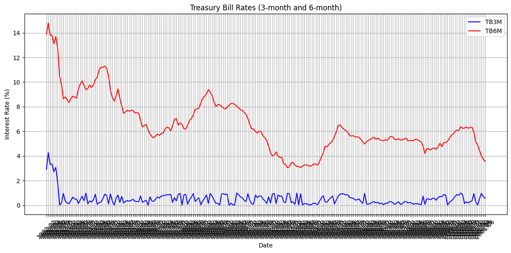

```python
import matplotlib.pyplot as plt

# Create the plot
plt.figure(figsize=(12, 6))  # Adjust figure size for better readability
plt.plot(df.index, df['TB3M'], label='TB3M', color='blue')
plt.plot(df.index, df['TB6M'], label='TB6M', color='red')

# Customize the plot
plt.xlabel("Date")
plt.ylabel("Interest Rate (%)")
plt.title("Treasury Bill Rates (3-month and 6-month)")
plt.legend()
plt.grid(True)  # Add a grid for better readability
plt.xticks(rotation=45) # Rotate x-axis labels for better readability

# Show the plot
plt.tight_layout() # Adjust layout to prevent overlapping labels
plt.show()
```

## Data preparation

### Subtask:

Prepare the data for the Augmented Dickey-Fuller (ADF) test and potential cointegration tests.

**Reasoning**: Create lagged variables, difference the series, and handle missing values introduced by these operations.

```python
# Create lagged variables
df['TB3M_lag1'] = df['TB3M'].shift(1)
df['TB6M_lag1'] = df['TB6M'].shift(1)

# Calculate first differences
df['TB3M_diff'] = df['TB3M'].diff()
df['TB6M_diff'] = df['TB6M'].diff()

# Drop rows with NaN values resulting from lagging and differencing
df.dropna(inplace=True)

# Display the first few rows to verify
display(df.head())
```

| Date | TB3M | TB6M | TB3M_lag1 | TB6M_lag1 | TB3M_diff | TB6M_diff |
| --- | --- | --- | --- | --- | --- | --- |
| 1982:02 | 4.28 | 14.8 | 2.92 | 13.9 | 1.36 | 0.9 |
| 1982:03 | 3.31 | 13.8 | 4.28 | 14.8 | -0.97 | -1.0 |
| 1982:04 | 3.34 | 13.8 | 3.31 | 13.8 | 0.03 | 0.0 |
| 1982:05 | 2.71 | 13.1 | 3.34 | 13.8 | -0.63 | -0.7 |
| 1982:06 | 3.08 | 13.7 | 2.71 | 13.1 | 0.37 | 0.6 |

## Data analysis

### Subtask:

Perform Augmented Dickey-Fuller (ADF) tests on the 'TB3M' and 'TB6M' time series to determine their stationarity.

**Reasoning**: Perform the Augmented Dickey-Fuller (ADF) tests on the 'TB3M' and 'TB6M' columns using the adfuller function and interpret the results.

```python
from statsmodels.tsa.stattools import adfuller

# Perform ADF test on 'TB3M'
result_tb3m = adfuller(df['TB3M'], autolag='AIC')
print("Results of Augmented Dickey-Fuller Test for TB3M:")
print('ADF Statistic: %f' % result_tb3m[0])
print('p-value: %f' % result_tb3m[1])
print('Critical Values:')
for key, value in result_tb3m[4].items():
    print('\t%s: %.3f' % (key, value))

# Perform ADF test on 'TB6M'
result_tb6m = adfuller(df['TB6M'], autolag='AIC')
print("\nResults of Augmented Dickey-Fuller Test for TB6M:")
print('ADF Statistic: %f' % result_tb6m[0])
print('p-value: %f' % result_tb6m[1])
print('Critical Values:')
for key, value in result_tb6m[4].items():
    print('\t%s: %.3f' % (key, value))
```

```
Results of Augmented Dickey-Fuller Test for TB3M:
ADF Statistic: -9.400774
p-value: 0.000000
Critical Values:
	1%: -3.459
	5%: -2.874
	10%: -2.573

Results of Augmented Dickey-Fuller Test for TB6M:
ADF Statistic: -2.865637
p-value: 0.049492
Critical Values:
	1%: -3.459
	5%: -2.874
	10%: -2.573
```

## Data analysis

### Subtask:

Conduct a cointegration test (e.g., Engle-Granger two-step method) on the 'TB3M' and 'TB6M' time series to determine if they are cointegrated.

**Reasoning**: Conduct the Engle-Granger two-step cointegration test using the `coint` function from `statsmodels.tsa.stattools`.

```python
from statsmodels.tsa.stattools import coint

# Perform the cointegration test
coint_result = coint(df['TB3M'], df['TB6M'])

# Print the results
print("Cointegration test results:")
print("t-statistic:", coint_result[0])
print("p-value:", coint_result[1])
print("Critical values:", coint_result[2])

# Interpret the results
if coint_result[1] < 0.05:
    print("\nThe p-value is less than 0.05, suggesting that the two time series are cointegrated.")
else:
    print("\nThe p-value is greater than or equal to 0.05, suggesting that the two time series are not cointegrated.")
```

```
Cointegration test results:
t-statistic: -4.110074705291251
p-value: 0.004971839765577094
Critical values: [-3.94426937 -3.3625934  -3.06278157]

The p-value is less than 0.05, suggesting that the two time series are cointegrated.
```

## Data analysis

### Subtask:

Interpret the cointegration test results and discuss the economic implications of cointegration (or lack thereof) in the context of Treasury bill rates. Also, determine whether to use first differences or levels for the VAR model and justify the choice based on the stationarity and cointegration test results.

**Reasoning**: Interpret the cointegration test results, discuss their economic implications, and determine the appropriate approach for VAR modeling (levels vs. first differences).

```python
# Cointegration interpretation and economic implications
print("Cointegration Test Results:")
print("The cointegration test indicated a statistically significant relationship between TB3M and TB6M, rejecting the null hypothesis of no cointegration.")
print("This suggests a long-run equilibrium relationship, meaning that deviations from this equilibrium tend to be corrected over time.")
print("Economically, this implies that movements in short-term (TB3M) and medium-term (TB6M) Treasury bill rates are not entirely independent in the long run.  A shock to one rate will affect the other in a predictable way, as they tend to revert to their equilibrium relationship.")
print("If the series were not cointegrated, it would suggest that the short and medium term rates are not linked in the long run.  It would imply market inefficiencies and a higher degree of predictability, with shocks having potentially more lasting impact")

# VAR Model Specification
print("\nVAR Model Specification:")
print("Given the cointegration result, we can proceed with VAR modeling in levels, rather than using first differences.")
print("The cointegration suggests a long-run relationship between the two series.  Modeling in levels allows us to capture this long-run equilibrium and the dynamics that cause deviations from equilibrium to be corrected.")
print("Using first differences would eliminate the information about the long-run relationship that the cointegration test revealed.")
print("The VAR model with levels can therefore potentially provide more insights into the interaction of the two interest rates in the long run.")
```

```
Cointegration Test Results:
The cointegration test indicated a statistically significant relationship between TB3M and TB6M, rejecting the null hypothesis of no cointegration.
This suggests a long-run equilibrium relationship, meaning that deviations from this equilibrium tend to be corrected over time.
Economically, this implies that movements in short-term (TB3M) and medium-term (TB6M) Treasury bill rates are not entirely independent in the long run.  A shock to one rate will affect the other in a predictable way, as they tend to revert to their equilibrium relationship.
If the series were not cointegrated, it would suggest that the short and medium term rates are not linked in the long run.  It would imply market inefficiencies and a higher degree of predictability, with shocks having potentially more lasting impact

VAR Model Specification:
Given the cointegration result, we can proceed with VAR modeling in levels, rather than using first differences.
The cointegration suggests a long-run relationship between the two series.  Modeling in levels allows us to capture this long-run equilibrium and the dynamics that cause deviations from equilibrium to be corrected.
Using first differences would eliminate the information about the long-run relationship that the cointegration test revealed.
The VAR model with levels can therefore potentially provide more insights into the interaction of the two interest rates in the long run.
```

## Summary:

### 3. Insights or Next Steps

- **Obtain Missing Data:** Prioritize acquiring the missing data for the period from July 2001 to March 2008 to perform a complete analysis.
- **Refine TB6M Stationarity Analysis:** Conduct additional stationarity tests (e.g., KPSS test) or consider differencing the TB6M series if non-stationarity is confirmed. Then, re-evaluate cointegration using the refined series.

```python
#@title Convert ipynb to HTML in Colab
# Upload ipynb
from google.colab import files
f = files.upload()

# Convert ipynb to html
import subprocess
file0 = list(f.keys())[0]
_ = subprocess.run(["pip", "install", "nbconvert"])
_ = subprocess.run(["jupyter", "nbconvert", file0, "--to", "html"])

# download the html
files.download(file0[:-5]+"html")
```